# Target Limited Outreach Resources for Home Repair Tax Credit Program.

Michael Clifford and Shuai Wang

2023-11-02

The Department of Housing and Community Development (HCD) has been proactively reaching out to potential homeowners for a home repair tax credit program. However, the program has a low conversion rate and a high cost per successful applicant. It is evaluated that the houses that transacted after taking the credit can be sold with a $10,000 premium on average, and the homes surrounding the repaired home witness an aggregate premium of $56,000, on average. To maximize the benefit and minimize the cost of the program, a data-driven strategy is needed to prioritize the homeowners who are most likely to take the credit. By using the data from previous campaigns, we can predict the likelihood of a homeowner entering and taking the credit based on various indicators, including their characteristics and behavior, to inform a cost/benefit analysis that can optimize the allocation of outreach resources.

```r
options(scipen=10000000)

library(tidyverse)
library(kableExtra)
library(caret)
library(knitr)
library(pscl)
library(plotROC)
library(pROC)
library(lubridate)
library(stargazer)
```

```r
palette5 <- c("#981FAC","#CB0F8B","#FF006A","#FE4C35","#FE9900")
palette4 <- c("#981FAC","#FF006A","#FE4C35","#FE9900")
palette2 <- c("#981FAC","#FF006A")

housing <- read.csv("housingSubsidy.csv")
```

# Feature Importance and Correlation

The first section aims to explore the relationship of each indicator with the result of entering the program or not. Both numeric and categorical variables are examined to understand their importance and correlation.

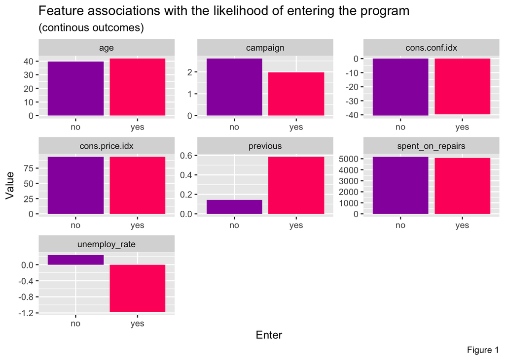

```r
housing %>%
  dplyr::select(y, age, campaign, previous, unemploy_rate, cons.price.idx,
                cons.conf.idx, spent_on_repairs) %>%
  gather(Variable, value, -y) %>%
    ggplot(aes(y, value, fill=y)) +
      geom_bar(position = "dodge", stat = "summary", fun = "mean") +
      facet_wrap(~Variable, scales = "free") +
      scale_fill_manual(values = palette2) +
      labs(x="Enter", y="Value",
           title = "Feature associations with the likelihood of entering the program",
           subtitle = "(continous outcomes)",
           caption = "Figure 1") +
      theme(legend.position = "none")
```

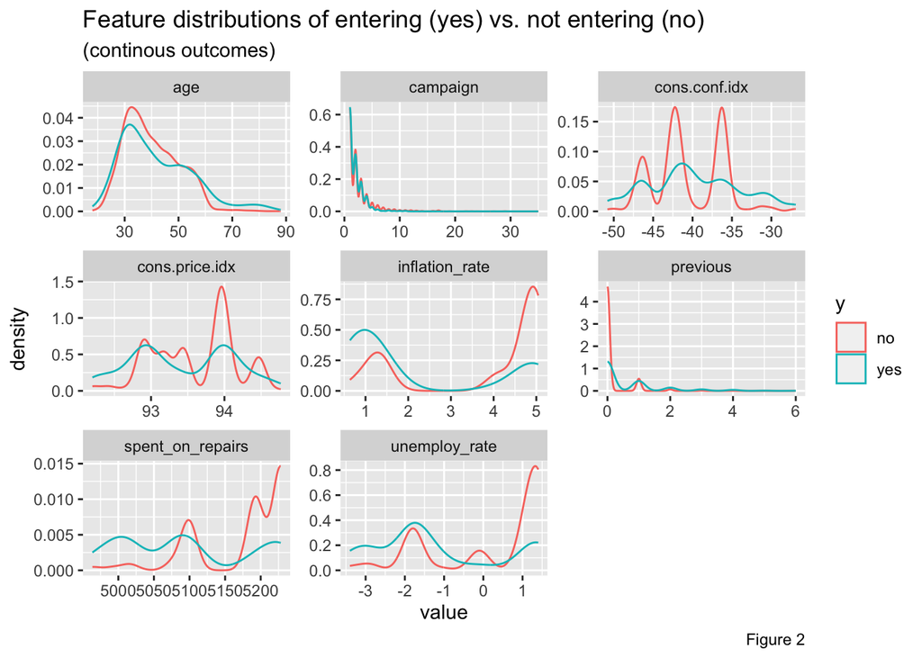

```r
housing %>%
    dplyr::select(y, age, campaign, previous, unemploy_rate, cons.price.idx,
                cons.conf.idx, spent_on_repairs, inflation_rate) %>%
    gather(Variable, value, -y) %>%
    ggplot() +
    geom_density(aes(value, color=y), fill = "transparent") +
    facet_wrap(~Variable, scales = "free") +
    scale_fill_manual(values = palette2, name = "Entered the program?") +
    labs(title = "Feature distributions of entering (yes) vs. not entering (no)",
         subtitle = "(continous outcomes)",
         caption = "Figure 2")
```

By exploring the numeric variables, it is found that there is a major difference in entering the program based on the age, consumer confidence, consumer price, inflation, previous contacts, money spent on repairs and the unemployment rate.

Because of the inadequate sensitivity of the existing variables, we engineered new variables that aim to enhance the predictability of the homeowners’ possibility to enter the program or not. They are: - edu (below and with high school degree, above high school degree, unknown), - season (Winter, Spring, Summer, Fall), - job.y.share (the share of people entering the program based on each type of job), - pdays_cat (whether the homeowner was contacted or not), - repair_cat (whether the house repair cost is less than $5175 or above).

```r
housing <- housing %>%
  mutate(edu = ifelse((education =="university.degree" | education =="professional.course"), "aboveHS", ifelse(education == "unknown" | is.na(education), "unknown", "belowHS")))

housing <- housing %>%
  mutate(season = case_when(
    month == "dec" | month == "jan" | month == "feb" ~ "Winter",
    month == "mar" | month == "apr" | month == "may" ~ "Spring",
    month == "jun" | month == "jul" | month == "aug" ~ "Summer",
    month == "sep" | month == "oct" | month == "nov" ~ "Fall"))

housing <- housing %>%
  group_by(job) %>%
  summarize(tot.y = sum(y_numeric),
            n = n(),
            job.y.share = 100*(tot.y/n)) %>%
  dplyr::select(-n, -tot.y) %>%
  right_join(housing, .)

housing <- housing %>%
  mutate(pdays_cat = ifelse(pdays == 999, "no", "yes"))

housing <- housing %>%
  mutate(repair_cat = ifelse(spent_on_repairs >= 5175, ">= 5175", "< 5175"))
```

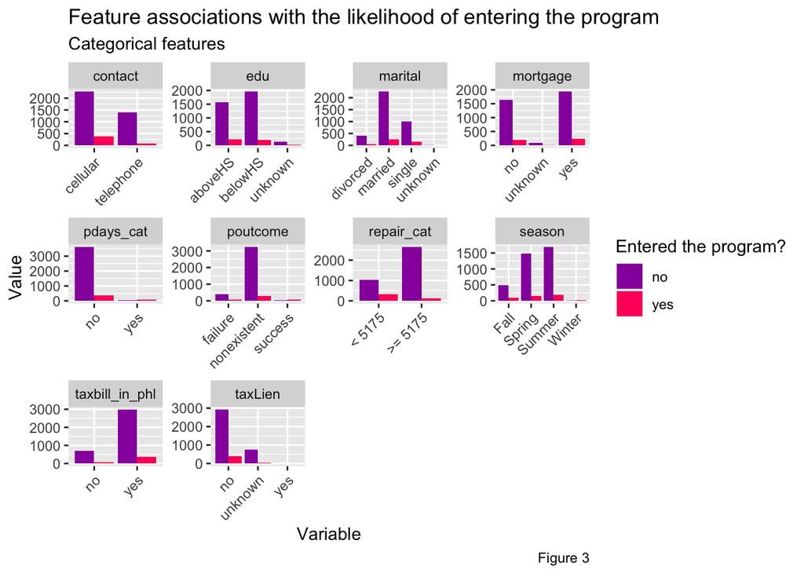

```r
housing %>%
    dplyr::select(y, marital, edu, mortgage, contact, poutcome, taxLien, taxbill_in_phl, season,
                  pdays_cat, repair_cat) %>%
    gather(Variable, value, -y) %>%
    count(Variable, value, y) %>%
      ggplot(., aes(value, n, fill = y)) +
        geom_bar(position = "dodge", stat="identity") +
        facet_wrap(~Variable, scales="free") +
        scale_fill_manual(values = palette2, name = "Entered the program?") +
        labs(x="Variable", y="Value",
             title = "Feature associations with the likelihood of entering the program",
             subtitle = "Categorical features",
             caption = "Figure 3") +
        theme(axis.text.x = element_text(angle = 45, hjust = 1))
```

This figure shows that the homeowners who are contacted by cellular, have been previously contacted, have less money spent on house repair are more likely to enter the program.

# Model Evaluation

We ran both kitchen sink model and our feature engineered model. Based on the pseudo-R2 measures, it shows that the kitchen sink model is better than the feature engineered model in terms of explaining the variability in the outcome variable because the McFadden score of kitchen sink model is higher, which indicates a better fit to the data. Despite the effort to engineer new features, the kitchen sink model still has better fit. Nevertheless, new features can be used for more comprehensive examination of the real world issue as the McFadden score of feature engineered model is close to the kitchen sink model’s.

```r
set.seed(3456)
trainIndex <- createDataPartition(housing$y, p = .65,
                                  list = FALSE,
                                  times = 1)
housingTrain <- housing[ trainIndex,]
housingTest  <- housing[-trainIndex,]
```

```r
kitchenModel <- glm(y_numeric ~ .,
                  data=housingTrain %>%
                    dplyr::select(-edu, -job.y.share, -season, -taxLien, -pdays_cat, -repair_cat, -y),
                  family="binomial" (link="logit"))

summary(kitchenModel)
```

```
##
## Call:
## glm(formula = y_numeric ~ ., family = binomial(link = "logit"),
##     data = housingTrain %>% dplyr::select(-edu, -job.y.share,
##         -season, -taxLien, -pdays_cat, -repair_cat, -y))
##
## Coefficients:
##                                  Estimate   Std. Error z value Pr(>|z|)
## (Intercept)                  -62.19586855 131.70394125  -0.472   0.6368
## X                              0.00005255   0.00006002   0.875   0.3813
## age                            0.00383747   0.00851456   0.451   0.6522
## jobblue-collar                -0.19395586   0.26978580  -0.719   0.4722
## jobentrepreneur               -0.42432097   0.45743139  -0.928   0.3536
## jobhousemaid                  -0.60256812   0.55248641  -1.091   0.2754
## jobmanagement                 -0.29769569   0.30609923  -0.973   0.3308
## jobretired                    -0.06939378   0.37067663  -0.187   0.8515
## jobself-employed              -0.72267757   0.45910449  -1.574   0.1155
## jobservices                   -0.38063019   0.29988752  -1.269   0.2044
## jobstudent                    -0.58636850   0.47512363  -1.234   0.2172
## jobtechnician                 -0.07096711   0.23348744  -0.304   0.7612
## jobunemployed                  0.01409981   0.42873890   0.033   0.9738
## jobunknown                    -0.31265365   0.70013747  -0.447   0.6552
## maritalmarried                -0.00337158   0.23887853  -0.014   0.9887
## maritalsingle                 -0.03590931   0.27433401  -0.131   0.8959
## maritalunknown               -11.78756359 329.19219037  -0.036   0.9714
## educationbasic.6y              0.37735844   0.40058469   0.942   0.3462
## educationbasic.9y             -0.06335464   0.33936436  -0.187   0.8519
## educationhigh.school           0.14771239   0.32365191   0.456   0.6481
## educationilliterate          -13.27033316 882.74356255  -0.015   0.9880
## educationprofessional.course   0.17986922   0.35080890   0.513   0.6081
## educationuniversity.degree     0.30199002   0.32392782   0.932   0.3512
## educationunknown               0.34675034   0.41419957   0.837   0.4025
## mortgageunknown               -0.12385996   0.56929048  -0.218   0.8278
## mortgageyes                   -0.20775344   0.14287048  -1.454   0.1459
## taxbill_in_phlyes              0.18175191   0.20074694   0.905   0.3653
## contacttelephone              -0.63330786   0.28513527  -2.221   0.0263 *
## monthaug                       0.02148474   0.44373694   0.048   0.9614
## monthdec                       1.82243473   0.78002383   2.336   0.0195 *
## monthjul                       0.10188428   0.37384444   0.273   0.7852
## monthjun                       0.06395839   0.47202270   0.135   0.8922
```

[output cut: 14 more lines]

```
## unemploy_rate                 -0.93563334   0.48646189  -1.923   0.0544 .
## cons.price.idx                 0.89783251   0.86200128   1.042   0.2976
## cons.conf.idx                  0.02113176   0.02936107   0.720   0.4717
## inflation_rate                 0.51062205   0.44835667   1.139   0.2548
## spent_on_repairs              -0.00477565   0.01074639  -0.444   0.6568
## ---
## Signif. codes:  0 '***' 0.001 '**' 0.01 '*' 0.05 '.' 0.1 ' ' 1
##
## (Dispersion parameter for binomial family taken to be 1)
##
##     Null deviance: 1853.7  on 2678  degrees of freedom
## Residual deviance: 1488.2  on 2628  degrees of freedom
## AIC: 1590.2
##
## Number of Fisher Scoring iterations: 13
```

```r
housingModel  <- glm(y_numeric ~ .,
                  data=housingTrain %>%
                    dplyr::select(-age, -month, -education, -previous,
                                  -pdays, -job, -taxLien, -spent_on_repairs, -cons.price.idx,
                                  -inflation_rate,
                                   -X, -y),
                  family="binomial" (link="logit"))

summary(housingModel)
```

```
##
## Call:
## glm(formula = y_numeric ~ ., family = binomial(link = "logit"),
##     data = housingTrain %>% dplyr::select(-age, -month, -education,
##         -previous, -pdays, -job, -taxLien, -spent_on_repairs,
##         -cons.price.idx, -inflation_rate, -X, -y))
##
## Coefficients:
##                      Estimate Std. Error z value Pr(>|z|)
## (Intercept)          -0.23744    1.03779  -0.229  0.81903
## maritalmarried       -0.07136    0.22898  -0.312  0.75532
## maritalsingle        -0.11270    0.24346  -0.463  0.64343
## maritalunknown      -11.94280  329.17589  -0.036  0.97106
## mortgageunknown      -0.03075    0.52010  -0.059  0.95286
## mortgageyes          -0.20384    0.13864  -1.470  0.14147
## taxbill_in_phlyes     0.18347    0.19521   0.940  0.34729
## contacttelephone     -0.11557    0.18718  -0.617  0.53695
## day_of_weekmon       -0.27346    0.21349  -1.281  0.20023
## day_of_weekthu       -0.15985    0.20947  -0.763  0.44539
## day_of_weektue       -0.18710    0.21007  -0.891  0.37313
## day_of_weekwed       -0.28760    0.22447  -1.281  0.20011
## campaign             -0.11689    0.04314  -2.709  0.00674 **
## poutcomenonexistent   0.32878    0.21759   1.511  0.13079
## poutcomesuccess       0.97668    0.64072   1.524  0.12742
## unemploy_rate        -0.01204    0.15029  -0.080  0.93613
## cons.conf.idx         0.02433    0.01631   1.492  0.13577
## edubelowHS           -0.26040    0.14349  -1.815  0.06955 .
## eduunknown           -0.01677    0.31751  -0.053  0.95788
## seasonSpring         -0.51882    0.24203  -2.144  0.03207 *
## seasonSummer          0.13350    0.22230   0.601  0.54813
## seasonWinter          2.02543    0.67530   2.999  0.00271 **
## job.y.share           0.02324    0.01601   1.451  0.14675
## pdays_catyes          1.09585    0.63416   1.728  0.08398 .
## repair_cat>= 5175    -1.47333    0.52369  -2.813  0.00490 **
## ---
## Signif. codes:  0 '***' 0.001 '**' 0.01 '*' 0.05 '.' 0.1 ' ' 1
##
## (Dispersion parameter for binomial family taken to be 1)
##
##     Null deviance: 1853.7  on 2678  degrees of freedom
## Residual deviance: 1546.0  on 2654  degrees of freedom
## AIC: 1596
##
## Number of Fisher Scoring iterations: 13
```

```r
#pR2(kitchenModel)
#pR2(housingModel)

stargazer(pR2(kitchenModel), type = "text", title = "KitchenModel's results of pseudo-R2 measures")
```

```
## fitting null model for pseudo-r2
##
## KitchenModel's results of pseudo-R2 measures
## ==============================================
## llh      llhNull    G2    McFadden r2ML  r2CU
## ----------------------------------------------
## -744.098 -926.871 365.547  0.197   0.128 0.255
## ----------------------------------------------
```

```r
stargazer(pR2(housingModel), type = "text", title = "HousingModel's results of pseudo-R2 measures")
```

```
## fitting null model for pseudo-r2
##
## HousingModel's results of pseudo-R2 measures
## ==============================================
## llh      llhNull    G2    McFadden r2ML  r2CU
## ----------------------------------------------
## -772.989 -926.871 307.764  0.166   0.109 0.217
## ----------------------------------------------
```

## Cross Validation

```r
testProbs.kit <- data.frame(Outcome = as.factor(housingTest$y_numeric),
                        Probs = predict(kitchenModel, housingTest, type= "response"))

testProbs <- data.frame(Outcome = as.factor(housingTest$y_numeric),
                        Probs = predict(housingModel, housingTest, type= "response"))
```

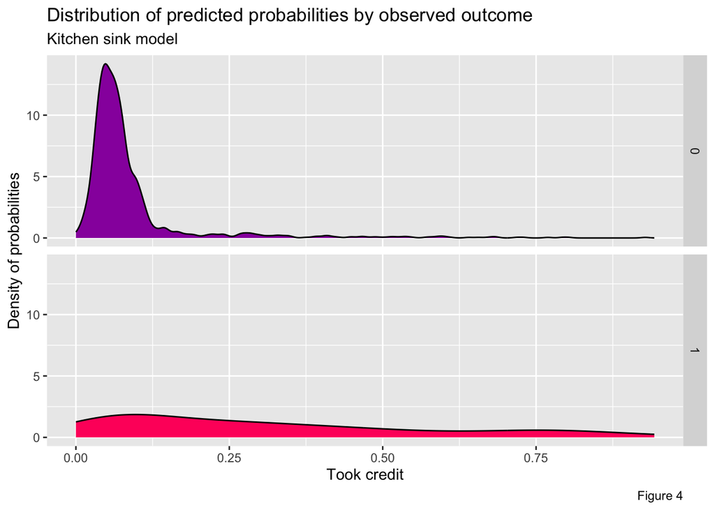

```r
ggplot(testProbs.kit, aes(x = Probs, fill = as.factor(Outcome))) +
  geom_density() +
  facet_grid(Outcome ~ .) +
  scale_fill_manual(values = palette2) +
  labs(x = "Took credit", y = "Density of probabilities",
       title = "Distribution of predicted probabilities by observed outcome",
       subtitle = "Kitchen sink model",
       caption = "Figure 4") +
  theme(strip.text.x = element_text(size = 18),
        legend.position = "none")
```

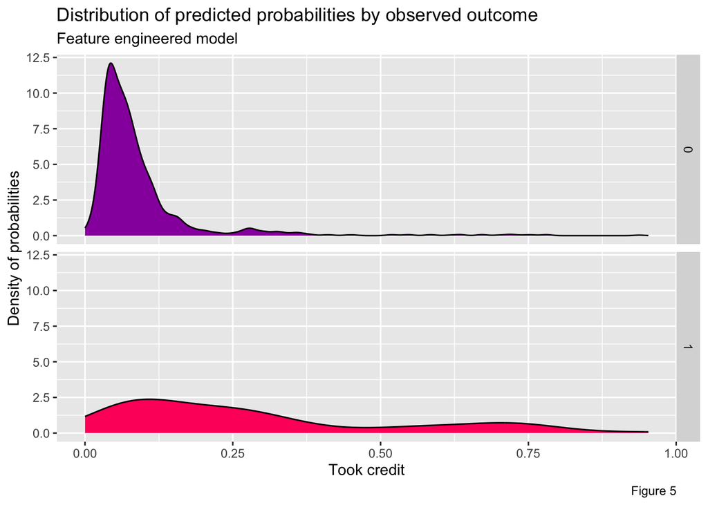

```r
ggplot(testProbs, aes(x = Probs, fill = as.factor(Outcome))) +
  geom_density() +
  facet_grid(Outcome ~ .) +
  scale_fill_manual(values = palette2) +
  labs(x = "Took credit", y = "Density of probabilities",
       title = "Distribution of predicted probabilities by observed outcome",
       subtitle = "Feature engineered model",
       caption = "Figure 5") +
  theme(strip.text.x = element_text(size = 18),
        legend.position = "none")
```

```r
testProbs.kit <-
  testProbs.kit %>%
  mutate(predOutcome  = as.factor(ifelse(testProbs.kit$Probs > 0.5 , 1, 0)))

testProbs <-
  testProbs %>%
  mutate(predOutcome  = as.factor(ifelse(testProbs$Probs > 0.5 , 1, 0)))
```

```r
caret::confusionMatrix(testProbs.kit$predOutcome, testProbs.kit$Outcome,
                       positive = "1")
```

```
## Confusion Matrix and Statistics
##
##           Reference
## Prediction    0    1
##          0 1258  121
##          1   25   36
##
##                Accuracy : 0.8986
##                  95% CI : (0.8819, 0.9137)
##     No Information Rate : 0.891
##     P-Value [Acc > NIR] : 0.1879
##
##                   Kappa : 0.2868
##
##  Mcnemar's Test P-Value : 0.000000000000003773
##
##             Sensitivity : 0.22930
##             Specificity : 0.98051
##          Pos Pred Value : 0.59016
##          Neg Pred Value : 0.91226
##              Prevalence : 0.10903
##          Detection Rate : 0.02500
##    Detection Prevalence : 0.04236
##       Balanced Accuracy : 0.60491
##
##        'Positive' Class : 1
##
```

```r
caret::confusionMatrix(testProbs$predOutcome, testProbs$Outcome,
                       positive = "1")
```

```
## Confusion Matrix and Statistics
##
##           Reference
## Prediction    0    1
##          0 1263  122
##          1   20   35
##
##                Accuracy : 0.9014
##                  95% CI : (0.8848, 0.9163)
##     No Information Rate : 0.891
##     P-Value [Acc > NIR] : 0.109
##
##                   Kappa : 0.29
##
##  Mcnemar's Test P-Value : <0.0000000000000002
##
##             Sensitivity : 0.22293
##             Specificity : 0.98441
##          Pos Pred Value : 0.63636
##          Neg Pred Value : 0.91191
##              Prevalence : 0.10903
##          Detection Rate : 0.02431
##    Detection Prevalence : 0.03819
##       Balanced Accuracy : 0.60367
##
##        'Positive' Class : 1
##
```

```r
#auc(testProbs.kit$Outcome, testProbs.kit$Probs)
#auc(testProbs$Outcome, testProbs$Probs)
```

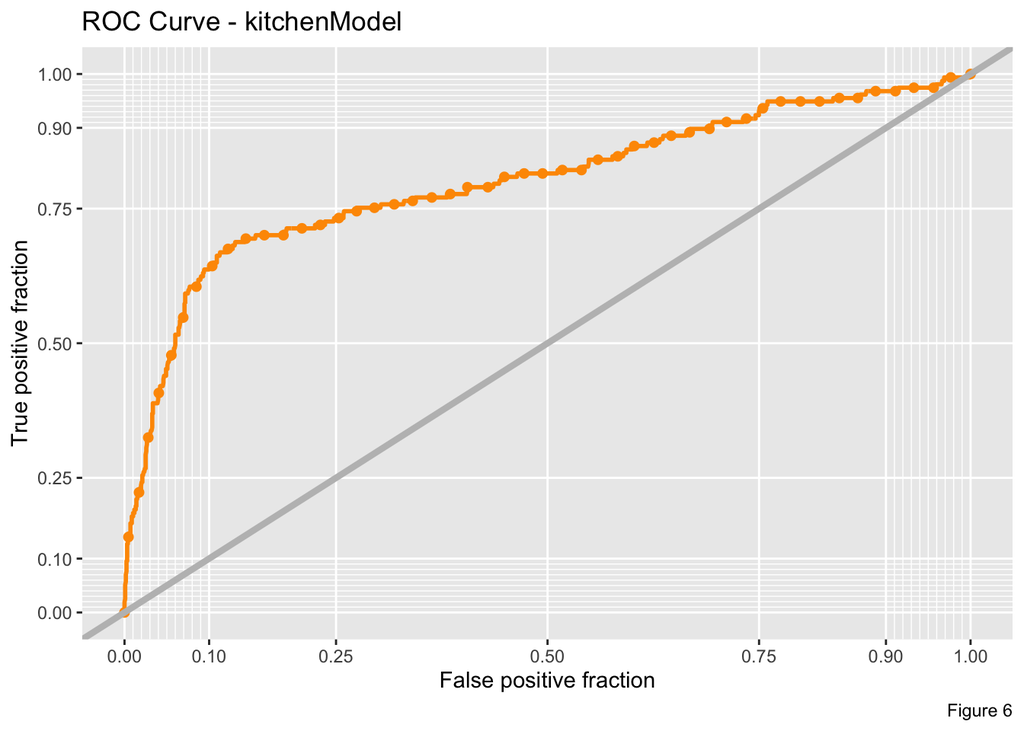

```r
ggplot(testProbs.kit, aes(d = as.numeric(Outcome), m = Probs)) +
  geom_roc(n.cuts = 50, labels = FALSE, colour = "#FE9900") +
  style_roc(theme = theme_grey) +
  geom_abline(slope = 1, intercept = 0, size = 1.5, color = 'grey') +
  labs(title = "ROC Curve - kitchenModel",
       caption = "Figure 6")
```

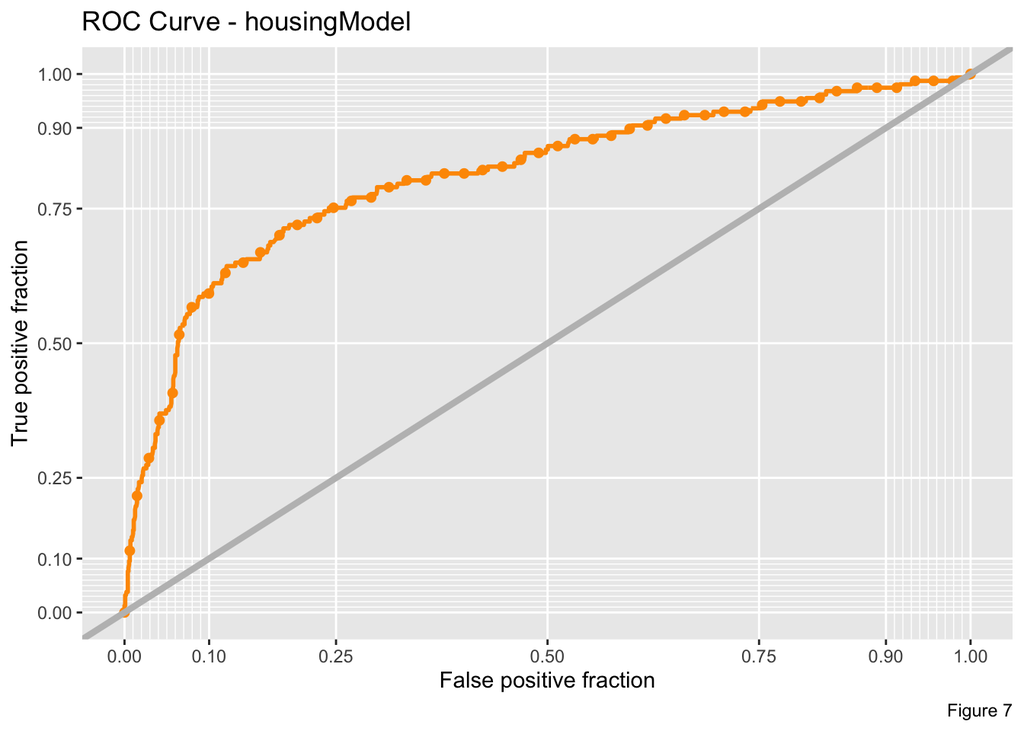

```r
ggplot(testProbs, aes(d = as.numeric(Outcome), m = Probs)) +
  geom_roc(n.cuts = 50, labels = FALSE, colour = "#FE9900") +
  style_roc(theme = theme_grey) +
  geom_abline(slope = 1, intercept = 0, size = 1.5, color = 'grey') +
  labs(title = "ROC Curve - housingModel",
       caption = "Figure 7")
```

```r
ctrl <- trainControl(method = "cv", number = 100, classProbs=TRUE, summaryFunction=twoClassSummary)


cvFit_kitchen <- train(y ~ .,
                  data=housing %>%
                   na.omit() %>%
                    dplyr::select(-edu, -job.y.share, -season, -taxLien, -y_numeric),
                method="glm", family="binomial",
                metric="ROC", trControl = ctrl)

cvFit_housing <- train(y ~ .,
                  data=housing %>%
                   na.omit() %>%
                    dplyr::select(-age, -month, -education,
                                    -pdays, -job, -taxLien, -X, -y_numeric),
                method="glm", family="binomial",
                metric="ROC", trControl = ctrl)

#cvFit_kitchen
#cvFit_housing
```

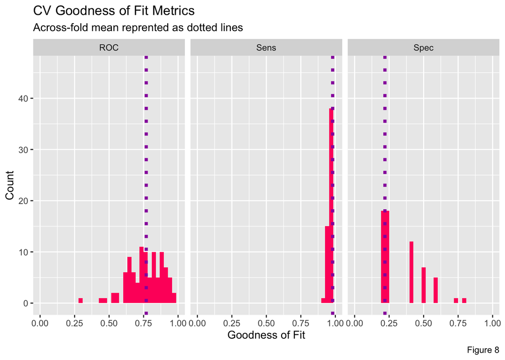

```r
dplyr::select(cvFit_kitchen$resample, -Resample) %>%
  gather(metric, value) %>%
  left_join(gather(cvFit_kitchen$results[2:4], metric, mean)) %>%
  ggplot(aes(value)) +
    geom_histogram(bins=35, fill = "#FF006A") +
    facet_wrap(~metric) +
    geom_vline(aes(xintercept = mean), colour = "#981FAC", linetype = 3, size = 1.5) +
    scale_x_continuous(limits = c(0, 1)) +
    labs(x="Goodness of Fit", y="Count", title="CV Goodness of Fit Metrics",
         subtitle = "Across-fold mean reprented as dotted lines",
         caption = "Figure 8")
```

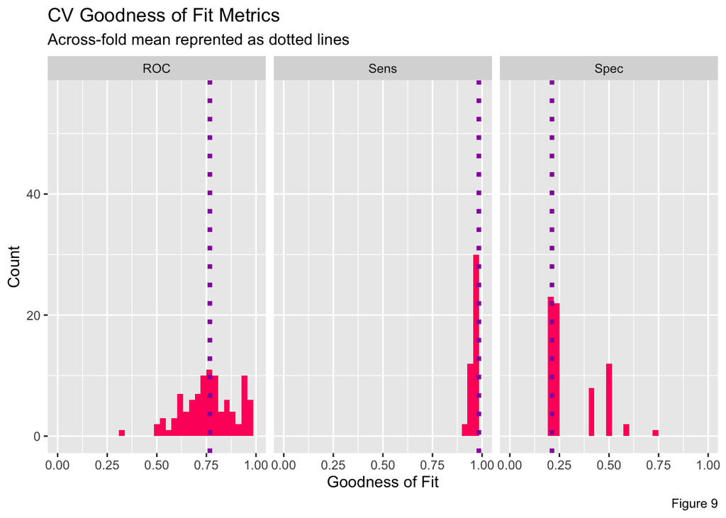

```r
dplyr::select(cvFit_housing$resample, -Resample) %>%
  gather(metric, value) %>%
  left_join(gather(cvFit_housing$results[2:4], metric, mean)) %>%
  ggplot(aes(value)) +
    geom_histogram(bins=35, fill = "#FF006A") +
    facet_wrap(~metric) +
    geom_vline(aes(xintercept = mean), colour = "#981FAC", linetype = 3, size = 1.5) +
    scale_x_continuous(limits = c(0, 1)) +
    labs(x="Goodness of Fit", y="Count", title="CV Goodness of Fit Metrics",
         subtitle = "Across-fold mean reprented as dotted lines",
         caption = "Figure 9")
```

We performed cross validation for both kitchen sink model and the feature engineered model. Both models are better at predicting negatives than positives. We used ROC curve as it visualizes trade-offs for two important confusion metrics, while also providing a single goodness of fit indicator. Both models show good fit as the curves are above the diagonal line with close values of ROC. Meanwhile, for the kitchen sink and featured engineered models, the sensitivity is 0.980 and 0.983 respectively, and the specificity is 0.219 and 0.212. The results indicate that both models have good sensibility that predict the result correctly.

# Cost-Benefit Analysis

- True Negative: no marketing resources were allocated, and no credit was allocated. True_Negative = Count * 0
- True Positive: allocated the marketing resources ($2,850), and 25% ultimately achieved the credit ($5,000), with $10,000 premium on average per household and an aggregate premium of $56,000 on average. True_Positive = (-2850) * Count - (5000 * .25) * Count + (10000 + 56000) * Count * .25
- False Negative: no marketing resources were allocated, and no credit was allocated. False_Negative = Count * 0
- False Positive: allocated the marketing resources ($2,850). False_Positive = (-2850) * Count

```r
cost_benefit_table <-
   testProbs %>%
      count(predOutcome, Outcome) %>%
      summarize(True_Negative = sum(n[predOutcome==0 & Outcome==0]),
                True_Positive = sum(n[predOutcome==1 & Outcome==1]),
                False_Negative = sum(n[predOutcome==0 & Outcome==1]),
                False_Positive = sum(n[predOutcome==1 & Outcome==0])) %>%
       gather(Variable, Count) %>%
       mutate(Revenue =
               ifelse(Variable == "True_Negative", Count * 0,
               ifelse(Variable == "True_Positive",((-2850) * Count - (1250) * Count + 16500 * Count),
               ifelse(Variable == "False_Negative", Count * 0,
               ifelse(Variable == "False_Positive", (-2850) * Count, 0))))) %>%
    bind_cols(data.frame(Description = c(
              "We correctly predicted not entering credit program",
              "We correctly predicted entering credit program",
              "We predicted not entering credit program and customer entered",
              "We predicted entering credit program and customer did not")))

kable(cost_benefit_table,
       caption = "Cost/Benefit Table") %>% kable_styling()
```

Cost/Benefit Table

| Variable | Count | Revenue | Description |
| --- | --- | --- | --- |
| True_Negative | 1263 | 0 | We correctly predicted not entering credit program |
| True_Positive | 35 | 434000 | We correctly predicted entering credit program |
| False_Negative | 122 | 0 | We predicted not entering credit program and customer entered |
| False_Positive | 20 | -57000 | We predicted entering credit program and customer did not |

```r
iterateThresholds <- function(data) {
  x = .01
  all_prediction <- data.frame()
  while (x <= 1) {

  this_prediction <-
      testProbs %>%
      mutate(predOutcome = ifelse(Probs > x, 1, 0)) %>%
      count(predOutcome, Outcome) %>%
      summarize(True_Negative = sum(n[predOutcome==0 & Outcome==0]),
                True_Positive = sum(n[predOutcome==1 & Outcome==1]),
                False_Negative = sum(n[predOutcome==0 & Outcome==1]),
                False_Positive = sum(n[predOutcome==1 & Outcome==0])) %>%
     gather(Variable, Count) %>%
     mutate(Revenue =
               ifelse(Variable == "True_Negative", Count * 0,
               ifelse(Variable == "True_Positive",((-2850) * Count - (1250) * Count + 16500 * Count),
               ifelse(Variable == "False_Negative", Count * 0,
               ifelse(Variable == "False_Positive", (-2850) * Count, 0)))),
            Threshold = x)

  all_prediction <- rbind(all_prediction, this_prediction)
  x <- x + .01
  }
return(all_prediction)
}
```

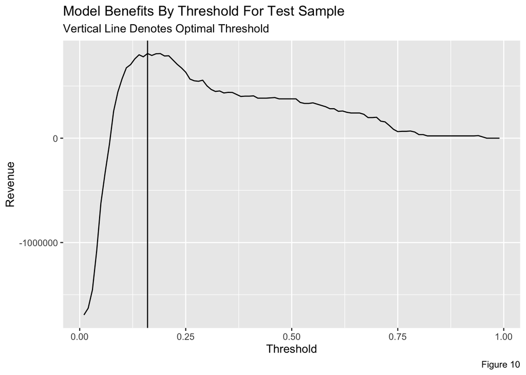

```r
whichThreshold <- iterateThresholds(testProbs)

whichThreshold_revenue <-
whichThreshold %>%
    group_by(Threshold) %>%
    summarize(Revenue = sum(Revenue))

  ggplot(whichThreshold_revenue)+
  geom_line(aes(x = Threshold, y = Revenue))+
  geom_vline(xintercept =  pull(arrange(whichThreshold_revenue, -Revenue)[1,1]))+
    labs(title = "Model Benefits By Threshold For Test Sample",
         subtitle = "Vertical Line Denotes Optimal Threshold",
         caption = "Figure 10")
```

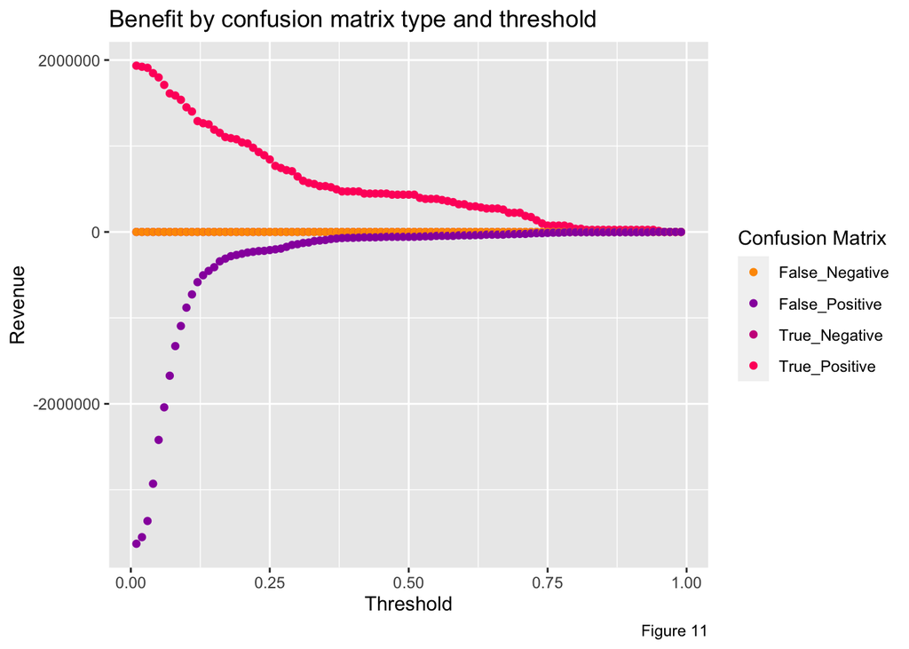

```r
whichThreshold %>%
  ggplot(.,aes(Threshold, Revenue, colour = Variable)) +
  geom_point() +
  scale_colour_manual(values = palette5[c(5, 1:3)]) +
  labs(title = "Benefit by confusion matrix type and threshold",
       y = "Revenue",
       caption = "Figure 11") +
  guides(colour=guide_legend(title = "Confusion Matrix"))
```